# D213 Advanced Data Analytics

## Performance Assessment Task 2

### A1: Research Question

Can a neural network be created that can accurately predict whether a review from a user is positive or negative?

### A2: Objective of Analysis

The purpose of this analysis is to attempt to create a neural network to see if we can accurately evaluate customer comments as positive or negative. The clients in this analysis are online websites that allow customers to leave a review on a product, movie, or business. The creation of such a model would allow these companies to provide real time analytics to the sellers, movie companies, or businesses on how their customers feel about their services. This would make their websites an invaluable resource not just to the customers leaving the reviews but also to the companies whose services are being reviewed.

### A3: Identification of Neural Network Type

The type of neural network that will be used for this analysis is an LSTM network. An LSTM network or Long Short-Term Memory network are a type of Recurrent Neural Network, which is commonly used for sequential data such as text or time series data. LSTM networks offer improved performance over traditional RNN networks due to their ability to capture long term dependencies in the data (Chaudhuri, 2024).

### B1: Exploratory Data Analysis

```python
import pandas as pd
import numpy as np
import matplotlib.pyplot as plt
%matplotlib inline
import seaborn as sns
```

```python
# read in csv files
amazon = pd.read_csv('amazon_cells_labelled.txt', sep= '\t', header=None, quoting=3)
imdb = pd.read_csv('imdb_labelled.txt', sep= '\t', header=None, quoting=3)
yelp = pd.read_csv('yelp_labelled.txt', sep= '\t', header=None, quoting=3)
```

```python
df = pd.concat([amazon, imdb, yelp], ignore_index=True) #join into single data frame
```

```python
df.columns = ['review', 'label'] #name columns
df.head() #inspect first five rows
```

|  | review | label |
| --- | --- | --- |
| 0 | So there is no way for me to plug it in here i... | 0 |
| 1 | Good case, Excellent value. | 1 |
| 2 | Great for the jawbone. | 1 |
| 3 | Tied to charger for conversations lasting more... | 0 |
| 4 | The mic is great. | 1 |

```python
df.info() #inspect data types of columns and check for null values
```

```
<class 'pandas.core.frame.DataFrame'>
RangeIndex: 3000 entries, 0 to 2999
Data columns (total 2 columns):
 #   Column  Non-Null Count  Dtype
---  ------  --------------  -----
 0   review  3000 non-null   object
 1   label   3000 non-null   int64
dtypes: int64(1), object(1)
memory usage: 47.0+ KB
```

```python
df['label'].value_counts() #check counts for labels column
```

```
0    1500
1    1500
Name: label, dtype: int64
```

In the cell below, we iterate through every character in every review and append them to a list and print it out. If we look at the entries at the end of the list we see a variety of unusual characters that will need to be removed before we analyze the data.

```python
# check for unusual characters in text
list_of_char = []

for row in df['review']:
    for char in row:
        if char not in list_of_char:
            list_of_char.append(char)

print(list_of_char)
```

```
['S', 'o', ' ', 't', 'h', 'e', 'r', 'i', 's', 'n', 'w', 'a', 'y', 'f', 'm', 'p', 'l', 'u', 'g', 'U', 'I', 'b', 'c', 'v', '.', 'G', 'd', ',', 'E', 'x', 'j', 'T', '4', '5', 'M', 'A', 'J', 'O', 'R', 'P', 'B', 'L', '!', 'z', 'N', 'W', 'q', 'H', '+', 'V', '"', 'Y', 'D', 'F', 'k', "'", 'K', 'C', '/', '7',…
```

```python
import re #for regular expressions
from sklearn.model_selection import train_test_split #splitting data into training and test sets
from tensorflow.keras.preprocessing.text import Tokenizer #tokenize reviews
from tensorflow.keras.callbacks import EarlyStopping #for stopping model training early
from tensorflow.keras.layers import Dense, Embedding, GlobalAveragePooling1D, Dropout, LSTM, Bidirectional #for building the layers of model
from tensorflow.keras.models import Sequential #model type
from tensorflow.keras.preprocessing.sequence import pad_sequences #padding sequences for use in model
from nltk.corpus import stopwords #for removing words from reviews
from nltk import word_tokenize #for tokenization
import nltk
```

```python
# download words for cleaning text
nltk.download('stopwords')
nltk.download('punkt')
nltk.download('wordnet')
```

```
True
```

```python
review_list = []
stop_words = stopwords.words('english')

for review in df['review']:
    review = re.sub("[^a-zA-Z]", ' ', review) #remove non-alphabet characters
    review = review.lower() #convert everything to lowercase
    review = word_tokenize(review)
    lemma = nltk.WordNetLemmatizer() #create lemmatizer to convert words to their dictionary form
    review = [lemma.lemmatize(word) for word in review] #lemmatize each word
    review = [word for word in review if not word in stop_words] #remove stop words
    review = " ".join(review) #rejoin words from original string back together
    review_list.append(review) #put cleaned descriptions into new list
```

##### Vocabulary Size

Below we use the word_index attribute of our tokenizer to count the number of unique words that appear in the reviews. We find that we have a vocabulary size of 4554. This number will be used later when we create the embedding layer of our model.

```python
# tokenizer and find vocabulary size
tokenizer = Tokenizer(num_words=10000, oov_token="<OOV>")
tokenizer.fit_on_texts(review_list)
print('Vocabulary Size:', len(tokenizer.word_index)+1)
```

```
Vocabulary Size: 4554
```

##### Embedding Length

A general rule of thumb is that the embedding length should be the fourth root of the vocabulary size (TensorFlow Team, 2017). In our case this gives us a value of 8.

```python
# find the embedding length
embed_len = int(round(np.sqrt(np.sqrt(4554)),0))
print('Embedding Length:', embed_len)
```

```
Embedding Length: 8
```

##### Sequence Length

For the initial maximum length of sequences, we used the average length of all the reviews which is 6. Looking at the histogram below we see that the length of our reviews is right skewed. Choosing the average length would allow us to reduce our sequences to a manageable size while still retaining the information for most of the reviews. However, after experimenting with longer sequence lengths, it was found that this was not the optimal size for our model. By iteratively increasing the maximum sequence length, we discovered that a maximum sequence length of 12 produced the optimal results for the model. Looking at the histogram, we see that the majority of our reviews fall below this length. This indicates that our initial chosen length of 6 was removing too much information from our data and harming the models ability to learn.

```python
#create a list containing the length of every review
review_length = []
for review in review_list:
    review_length.append(len(review.split(' ')))

max_length = np.max(review_length)
min_length = np.min(review_length)
median_length = np.median(review_length)
average_length = int(round(np.mean(review_length), 0))
print('Longest Review:', max_length)
print('Shortest Review:', min_length)
print('Median Review:', median_length)
print('Average Length:', average_length)
```

```
Longest Review: 44
Shortest Review: 1
Median Review: 5.0
Average Length: 6
```

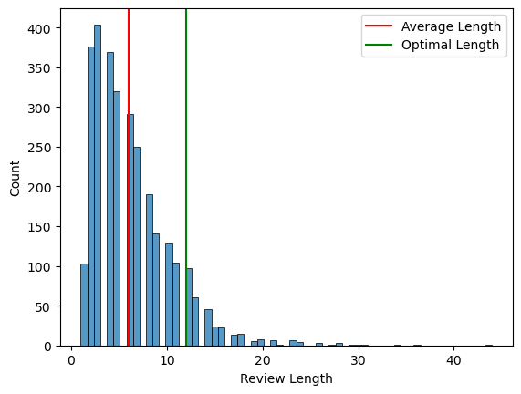

```python
sns.histplot(review_length)
plt.axvline(average_length, c='red', label='Average Length')
plt.axvline(12, c='green', label='Optimal Length')
plt.legend()
plt.xlabel('Review Length')
plt.show()
```

### B5: Data Preparation

The following process was used to prepare the data for analysis.

1. Check the data for null values.
2. Ensure the variables have the correct data type.
3. Remove all non-alphabet characters from the review column.
4. Convert all the reviews to lowercase.
5. Lemmatize the words in each review.

Lemmatizing is a form of text regularization that takes each word and converting to its base dictionary form. For example, the word ran would be changed to run after lemmatization. This is done to reduce the amount of randomness in the data and make it easier for the neural network to process (Yse, 2021).

6. Append the cleaned reviews into a list of lists.
7. Split the data into training and test sets with 20% of the data being set aside for the test set.
8. Tokenize and convert the cleaned reviews into sequences.
9. Pad the sequences.

```python
X = np.array(review_list) #convert list of cleaned reviews to array
y = df['label'].values

#split into training and testing sets
X_train, X_test, y_train, y_test = train_test_split(X, y, test_size=0.2, random_state=123, stratify=y)

y_train = pd.Series(y_train)
y_test = pd.Series(y_test)

print('Training Size:', X_train.shape)
print('Testing Size:', X_test.shape)
```

```
Training Size: (2400,)
Testing Size: (600,)
```

### B2: Goals of Tokenization

The purpose of tokenization is to break down the data into smaller pieces or tokens where each unique token is given its own numerical value. The data is then converted to a sequence of numbers where each number represents the token for the original text that was at that position. This process allows us to convert human language into a form that can be processed by machines and allows them to more easily recognize patterns within the data (Awan, 2023).

```python
sequences_train = tokenizer.texts_to_sequences(X_train)

sequences_test = tokenizer.texts_to_sequences(X_test)
```

### B3: Sequence Padding

Padding is a process whereby we make all of our sequences of equal length by adding zeros onto them. This is done because our neural network requires all of the input sequences to be of equal length. For this analysis, all sequences below the determined length had zeros added on to the end of the sequence. This was done using the pad_sequences function from tensorflow.keras.preprocessing.sequences.

```python
maxlen = 12 # maximum length of sequences

padded_train = pad_sequences(sequences_train, maxlen=maxlen, padding='post', truncating='post')

padded_test = pad_sequences(sequences_test, maxlen=maxlen, padding='post', truncating='post')
```

```python
padded_train[1]
```

```
array([ 234,   44, 3568, 3569,   30,    2,  822,   62,  283,  830,    0,
          0])
```

```python
training_padded = np.array(padded_train)
training_label = np.array(y_train)
test_padded = np.array(padded_test)
test_label = np.array(y_test)
```

### B4: Sentiment and Activation Function

There are two categories of sentiment used in this analysis, positive and negative. A positive review is represented by a 1 and a negative review is represented by a 0.

Since we only have two categories of sentiment that are labeled with zeros and ones, we will use an output layer with a single node and a sigmoid activation function. The sigmoid activation function takes the inputs from the final hidden layer and converts it to a value between 0 and 1 (Sharma, 2017). This output can be seen as the probility of the analyzed text being positive or negative. If the output is greater than or equal to 0.5 then the review will be predicted to have been positve. Similarly the review will be predicted to be negative should the output be less than 0.5.

### B6: Copy of Data Set

```python
df_train_rev = pd.DataFrame(training_padded)
df_train_labels = pd.DataFrame(training_label)
df_test_rev = pd.DataFrame(test_padded)
df_test_labels = pd.DataFrame(test_label)

#export data to csv files
#code has been commented out to prevent the creation of multiple copies
#df_train_rev.to_csv('review_train_pa2.csv')
#df_train_labels.to_csv('labels_train_pa2.csv')
#df_test_rev.to_csv('review_test_pa2.csv')
#df_test_labels.to_csv('labels_test_pa2.csv')
```

### C1: Output and Model Summary

```python
callback = EarlyStopping(patience=2)

model = Sequential()
model.add(Embedding(4554, embed_len, input_length=maxlen))
model.add(LSTM(20, dropout=0.5))
model.add(Dropout(0.25))
model.add(Dense(125, activation='relu'))
model.add(Dense(1, activation='sigmoid'))

model.compile(loss='binary_crossentropy', optimizer='adam', metrics=['accuracy'])
model.summary()
```

```
Model: "sequential"
_________________________________________________________________
Layer (type)                 Output Shape              Param #
=================================================================
embedding (Embedding)        (None, 12, 8)             36432
_________________________________________________________________
lstm (LSTM)                  (None, 20)                2320
_________________________________________________________________
dropout (Dropout)            (None, 20)                0
_________________________________________________________________
dense (Dense)                (None, 125)               2625
_________________________________________________________________
dense_1 (Dense)              (None, 1)                 126
=================================================================
Total params: 41,503
Trainable params: 41,503
Non-trainable params: 0
_________________________________________________________________
```

```python
#fit the model
history = model.fit(training_padded, training_label, epochs=20, callbacks=[callback],
                    batch_size=64, validation_split=0.2, verbose=1)
```

[output not shown]

```python
# evaluate model using test data
score = model.evaluate(test_padded, test_label)
print('Loss:', round(score[0], 4))
print('Accuracy:', round(score[1], 4))
```

```
Loss: 0.5656
Accuracy: 0.75
```

### C2: Layers and Parameters

The model consists of an input layer, 4 hidden layers, and an output layer with 41,503 parameters. These layers are, in order, the input sequences, an embedding layer, an lstm layer with 20 nodes, a dropout layer, a dense layer with 125 nodes, and a dense layer with 1 node as the output layer.

The input layer is the sequence of numbers representing each review.

The embedding layer takes the input of our text sequences and converts each word to a multidimentional vector.

The lstm layer is a special kind of layer capable of identifying long term dependecies in the data.

The dropout layer is a special kind of layer that randomly sets a percentage of inputs to zero during training to prevent overfitting.

A dense layer is the most common type of layer found in neural networks. They are called dense because each node is connected to every node in the previous layer (Baeldung, 2024).

The output layer in this model in a dense layer with a single node and a sigmoid activation function to transform the inputs from the final hidden layer into a number between 0 and 1.

### C3: Hyperparameters

##### Activation Functions

Two different activation functions were used in the model. The first activation function used is ReLU or Rectified Linear Unit. ReLU is commonly used in hidden layers because it is easy to implement and is able to overcome some of the limitations of other functions (Sharma, 2017). The other activation used in the model is sigmoid. Sigmoid is used in the output layer because we have a single node with a binary prediction of either 0 or 1. Sigmoid works well for this application because it converts the inputs from the hidden layer into a value between 0 and 1, where the value represents the probability of the actual value being 1. For example, in our model, if the model outputs a value of 0.6 then the prediction would be considered to be 1, which means the model predicts the input review to be a positive review.

##### Nodes

The number of nodes for each layer was determined through repeated incrementation of a single layer to see if it improved the performance of the model. We first used smaller values for each layer and gradually increased the number of nodes until the model stopped showing improved performance. In the end, we chose 20 nodes for the LSTM layer and 125 nodes for the dense layer.

##### Loss Function

The loss function used for this analysis was binary cross entropy. This function was used because the we used a single node for the output layer which would return a binary output of 0 or 1.

##### Optimizer

Adam was used as the optimizer for the model. Adam is generally considered to be one of the best choices for an optimizer in neural networks. This is because it incorporates many of the advantages of other optimizers while eliminating the need to find a good learning to tune the model (Gupta, 2024).

##### Stopping Criteria

To prevent the model from overfitting and reduce training time, the EarlyStopping function was used. The EarlyStopping function when passed to the callbacks parameter of the fit method stops the model training when certain conditions are met. In this instance, the function would stop the model from continuing to train if the validation loss did not improve for two epochs. As a model trains, there is a risk of it overfitting the training to the point that it does not generalize well to unseen data. By using the EarlyStopping function, we can prevent this overfitting by interuppting the training when the validation metrics begin to decline or plateau. After testing multiple values for patience, it was found that a value of 2 produced the optimal results. Values longer than 2 tended to let the model train for too long and produced less than optimal results while a value of 1 tended to stop the training process before the model was able to fully optimize itself.

##### Evaluation Metric

Accuracy was used for the evaluation of the model. Since we are looking to see if we can whether or not we can create a model that can accurately distinguish between positive and negative reviews, then a metric that evaluates both was needed. Accuracy measures the models ability to correctly label all values and is suitable for this task. Had we only been interested in the models ability to correctly label reviews as positive, then a different metric such as precision would have been more appropriate.

### D2: Model Fit

The final accuracy of the model on the training data is 0.9068. The accuracy of the model on the test data is 0.75. Given the relatively large difference between the training accuracy and the test accuracy, we can say that the model has overfit the training data to some extent. However, it is still able to produce decent accuracy on the training data. To help produce a model that generalized better, we used dropout layers. Dropout layers randomly set a certain percentage of the inputs from the previous layer to zero during the training process. The purpose of this is to force the model to learn the more general features of the training data and prevent it from overlearning on noisy data (Yadav, 2024). The end result is our model is able to generalize relatively well despite having somewhat overfit the training data.

### D3: Training Visualization

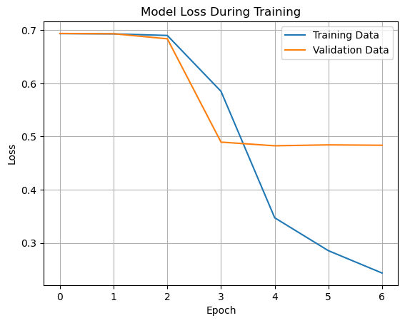

```python
plt.plot(history.history['loss'], label='Training Data') #plot the loss of the training data
plt.plot(history.history['val_loss'], label='Validation Data') #plot the loss of the testing data
plt.title('Model Loss During Training')
plt.xlabel('Epoch')
plt.ylabel('Loss')
plt.legend()
plt.grid()
plt.show()
```

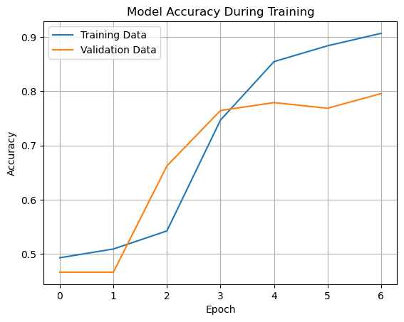

```python
plt.plot(history.history['accuracy'], label='Training Data') #plot the accuracy of the training data
plt.plot(history.history['val_accuracy'], label='Validation Data') #plot the accuracy of the test data
plt.title('Model Accuracy During Training')
plt.xlabel('Epoch')
plt.ylabel('Accuracy')
plt.legend()
plt.grid()
plt.show()
```

### D4: Model Accuracy

As stated in section D2, the predictive accuracy for our model is 0.75. Based on the visual titled "Model Accuracy During Training" from section D3, it is likely that this is as high of an accuracy as can be achieved with the current model. In the visual, we see that the validation accuracy is beginning to plataue and would likely have not increased much more had training continued.

### E: Saved Model Code

```python
#save model for use
#model.save('pa2_model.keras')
```

### F: Model Functionality

As discussed in previous sections, the predictive accuracy of our model is relatively good. However, it is likely not good enough to give much more than a very rough estimate of customer sentiment. This may be due to the size of our data set and how that limits our models ability to learn. Our data has a vocab size of around 4,500 which limits the number of embeddings that we can use for the model. We also only have around 2,400 samples in our training set which limits the ability of our model to find and recognize patterns that are more complex. For example, the model may have an easy time labeling a review that uses the word "terrible" as being negative, but may struggle with a review that uses more complex language to express negativity because we don't have enough training data for the model to learn those patterns.

### G: Recommendation

As discussed in the previous section, it is likely that we simply do not have enough data to produce a model that is able to generalize better than the one we currently have. Therefore, it is our recommendation to seek out more data to add on to our existing data and then revisit the model created in this analysis to see if a better model can be produced.

### I: Code Sources

No external code sources were used for this analysis.

### K: Text Sources

Awan, A. A. (2023, Sep). *What is Tokenization*. DataCamp. https://www.datacamp.com/blog/what-is-tokenization

Baeldung (2024, Mar 18). *The Concepts of Dense and Sparse in the Context of Neural Networks*. Baeldung. https://www.baeldung.com/cs/neural-networks-dense-sparse

Chaudhuri, K. D. (2024, June 12). *Sentiment Analysis with LSTM*. Analytics Vidhya. https://www.analyticsvidhya.com/blog/2022/01/sentiment-analysis-with-lstm/

Gupta, A. (2024, July 10). *A Comprehensive Guide on Optimizers in Deep Learning*. Analytics Vidhya. https://www.analyticsvidhya.com/blog/2021/10/a-comprehensive-guide-on-deep-learning-optimizers/#:~:text=Adagrad%20works%20better%20than%20stochastic,which%20the%20gradients%20are%20calculated.

Sharma, S. (2017, Sep 6). *Activation Functions in Neural Networks*. Towards Data Science. https://towardsdatascience.com/activation-functions-neural-networks-1cbd9f8d91d6

TensorFlow Team (2017, Nov 20). *Introducing TensorFlow Feature Columns*. Google for Developers. https://developers.googleblog.com/en/introducing-tensorflow-feature-columns/

Yadav, H. (2022, July 4). *Dropout in Neural Networks*. Towards Data Science. https://towardsdatascience.com/dropout-in-neural-networks-47a162d621d9

Yse, D. L. (2021, Feb 17). *Text Normalization fo Natural Language Processing*. Towards Data Science. https://towardsdatascience.com/text-normalization-for-natural-language-processing-nlp-70a314bfa646